# Cluster Analysis

Arqueología Cuantitativa

Esteban Arroyo y Patricio de Souza

25-10-2022

## Primero instalamos/llamamos los paquetes que necesitamos en esta sesión

```r
#install.packages("dplyr")
#install.packages("factoextra")
#install.packages("NbClust")
library(dplyr)
library(factoextra)
library(NbClust)
```

```r
library(ggplot2)
library(janitor)
library(flextable)
```

## Luego definimos la ubicacion en el directorio

```r
setwd("C:/Users/eluis/Documents/Clases_Estadistica/Conglomerado_script")
```

## Despues leemos el fichero de excel

```r
library("readxl")
data_set<-read_excel("BD_Clase8.xlsx", sheet="Hoja1")
```

### Hacemos un preview de los datos

```r
head(data_set) %>% flextable() %>% set_caption("Base Niveles") %>%
  bg(bg="#0000FF", part = "header") %>% bold(part = "header") %>%
  color(color = "white", part = "header") %>% autofit()
```

Base Niveles

| Sitio | Capa | Periodo | MP | Largo | Ancho_max | Ancho_plataforma | Peso | N°_de_negativos | Corteza en el anverso |
| --- | --- | --- | --- | --- | --- | --- | --- | --- | --- |
| Sitio1 | 3 | Arcaico | Basalto | 17.7 | 14.4 | 7.8 | 1.1 | 2 | Presente |
| Sitio1 | 2 | Agroalfarero | Basalto | 18.6 | 15.2 | 8.2 | 1.2 | 2 | Ausente |
| Sitio1 | 2 | Agroalfarero | Basalto | 18.6 | 17.0 | 6.4 | 1.6 | 3 | Ausente |
| Sitio1 | 4 | Arcaico | Basalto | 18.8 | 15.3 | 7.2 | 1.4 | 1 | Presente |
| Sitio1 | 2 | Agroalfarero | Basalto | 20.8 | 18.9 | 9.2 | 2.1 | 2 | Ausente |
| Sitio2 | 1 | Agroalfarero | Basalto | 21.0 | 16.0 | 10.6 | 2.1 | 4 | Ausente |

## Para los fines de esta actividad, debemos crear un dataframe que contenga sólo las variables que queremos incluir en el análisis de conglomerados. En esta ocasión trabajaremos sólo con los desechos líticos de Obsidiana para hacer más abordables los conglomerados

```r
df <- subset(data_set,MP=="Obsidiana")
#df <- df %>% select(-Sitio,-Capa,-Periodo,-MP,-Peso,-"N°_de_negativos",-"Corteza en el anverso") # Aquí eliminamos las columnas que no queremos
#df <- df %>% select(Largo, Ancho_max, Ancho_plataforma)  # Aquí conservamos las columnas que necesito
df <- select(df, c("Largo", "Ancho_max", "Ancho_plataforma"))  # Otra forma de hacer lo mismo sin usar los pipe "%>%"
summary(df)
```

```
##      Largo         Ancho_max     Ancho_plataforma
##  Min.   :15.30   Min.   : 6.50   Min.   : 4.200
##  1st Qu.:17.77   1st Qu.:12.53   1st Qu.: 6.800
##  Median :20.35   Median :15.05   Median : 8.600
##  Mean   :22.37   Mean   :16.40   Mean   : 9.345
##  3rd Qu.:26.45   3rd Qu.:21.25   3rd Qu.:13.050
##  Max.   :35.30   Max.   :28.70   Max.   :14.000
```

# 1.- Clústeres Jerárquicos

## Primero vamos con los clústeres Jerárquicos

## Para ello, creamos la matriz de distancias. Para este ejercicio ocuparemos la distancia euclidea

```r
mdist <- dist(df,method="euclidean")
```

## Ahora podemos calcular nuestros clústers, empezando por los jerárquicos. Probamos con el método de Ward y el de Average Linkage. En base a los dendrogramas obtenidos, podemos concluir que existen dos conglomerados, que se corresponden con los mismos objetos en ambos métodos

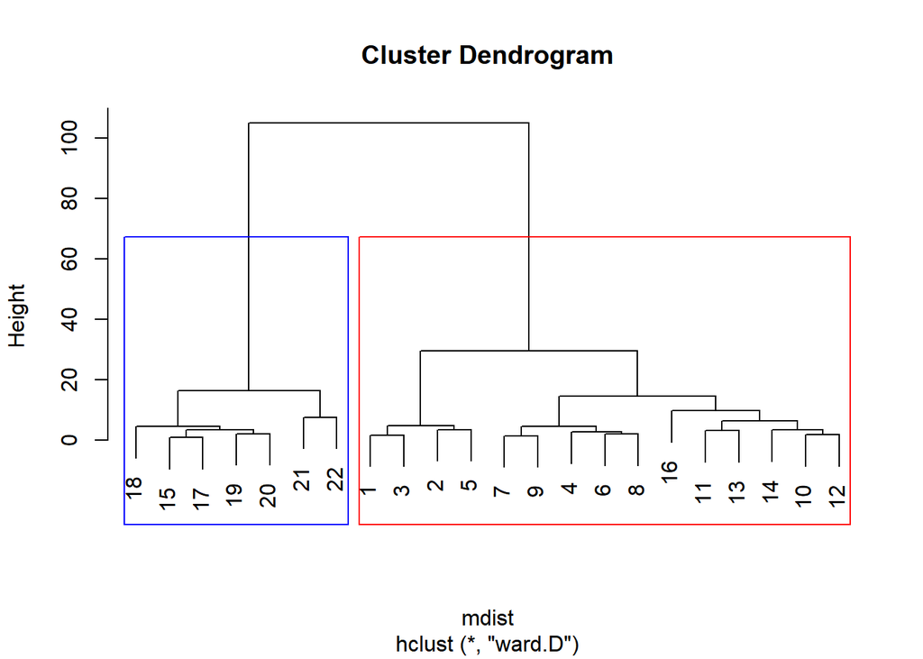

```r
clusterj1 <- hclust(mdist, method = "ward.D")
plot(clusterj1)
rect.hclust(clusterj1 , k = 2, border = c("blue","red"))
```

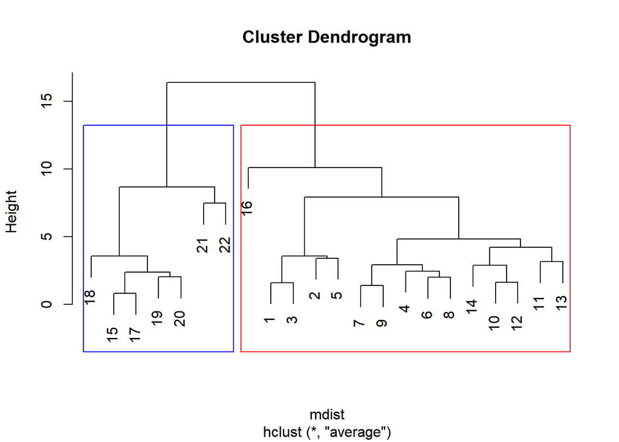

```r
clusterj2 <- hclust(mdist, method = "average")
plot(clusterj2)
rect.hclust(clusterj2 , k = 2, border = c("blue","red"))
```

# 2.- clústeres no-jerárquicos (k-medias)

## Ahora vamos con los clústeres no-jerárquicos (k-medias). Primero hacemos un gráfico de sedimentación para que nos de una idea de cuántos clústeres especificar. Aquí podemos ver una concordancia con lo que vimos en los dendrogramas de los clústeres jerárquicos, con 2 conglomerados como la mejor opción.

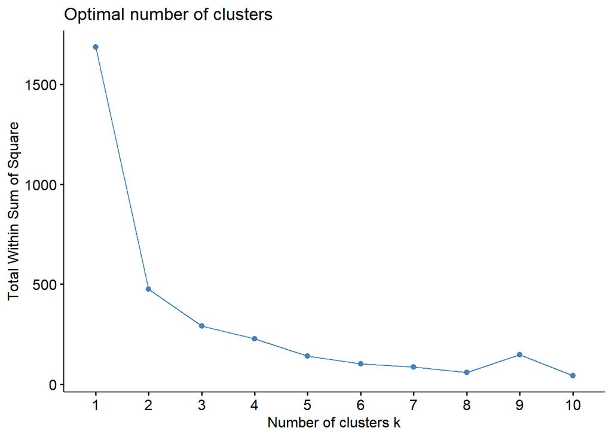

```r
fviz_nbclust(df, kmeans, method = "wss")
```

## Una opción interesante que nos ofrece R es la de calcular distintos índices para poder decidir la cantidad de conglomerados. Vemos que la mayoría sugiere 2 como el mejor k

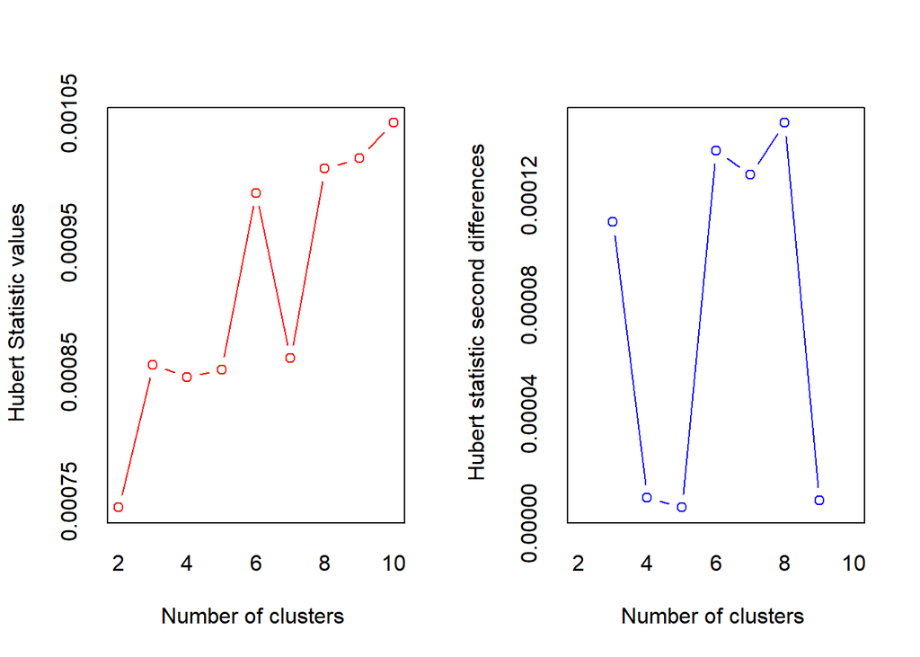

```
## *** : The Hubert index is a graphical method of determining the number of clusters.
##                 In the plot of Hubert index, we seek a significant knee that corresponds to a
##                 significant increase of the value of the measure i.e the significant peak in Hubert
##                 index second differences plot.
##
```

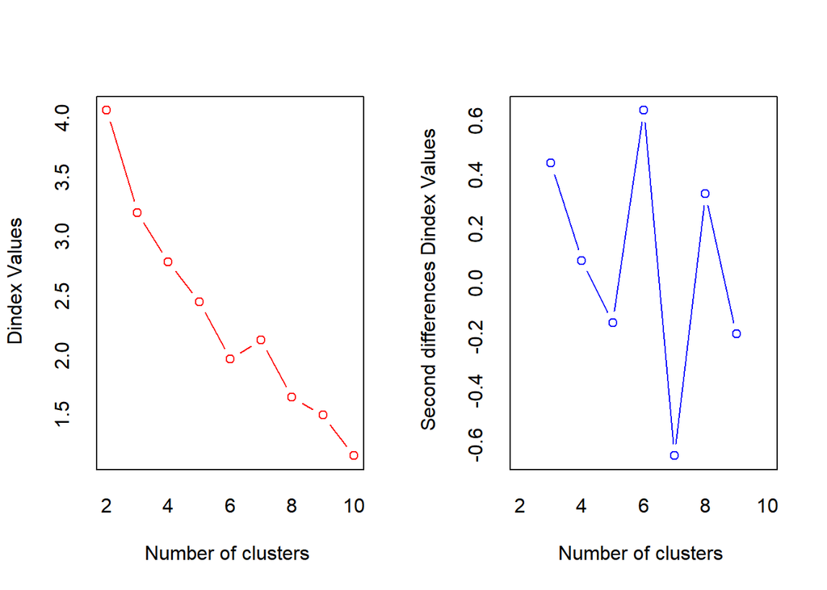

```
## *** : The D index is a graphical method of determining the number of clusters.
##                 In the plot of D index, we seek a significant knee (the significant peak in Dindex
##                 second differences plot) that corresponds to a significant increase of the value of
##                 the measure.
##
## * Among all indices:
## * 11 proposed 2 as the best number of clusters
## * 3 proposed 3 as the best number of clusters
## * 3 proposed 6 as the best number of clusters
## * 1 proposed 7 as the best number of clusters
## * 3 proposed 8 as the best number of clusters
## * 1 proposed 9 as the best number of clusters
## * 6 proposed 10 as the best number of clusters
##
##                    ***** Conclusion *****
##
## * According to the majority rule, the best number of clusters is  2
##
##
```

```r
nclusters <- NbClust(df, distance = "euclidean", min.nc=2, max.nc=10, method = "kmeans", index = "alllong")
```

## Ahora que nos decidimos por k=2, calculamos los clústeres no-jerárquicos

```r
set.seed (1) #Sembramos una semilla para que siempre los resultados sean los mismos
k2 <- kmeans(df, centers = 2, nstart = 22)
k2 %>% as_flextable() %>% theme_zebra()
```

| variable |  | 1 |  | 2 |
| --- | --- | --- | --- | --- |
| withinss |  | 263.9 |  | 210.8 |
| size |  | 14 |  | 8 |
| Largo* |  | 18.5643 |  | 29.0375 |
| Ancho_max* |  | 12.8786 |  | 22.5500 |
| Ancho_plataforma* |  | 7.2000 |  | 13.1000 |

(*) Centers  
Total sum of squares: 1,686.5  
Total within-cluster sum of squares: 474.7  
Total between-cluster sum of squares: 1,211.8  
BSS/TSS ratio: 71.9%  
Number of iterations: 1

## Visualizamos los resultados del modelo final de k-medias

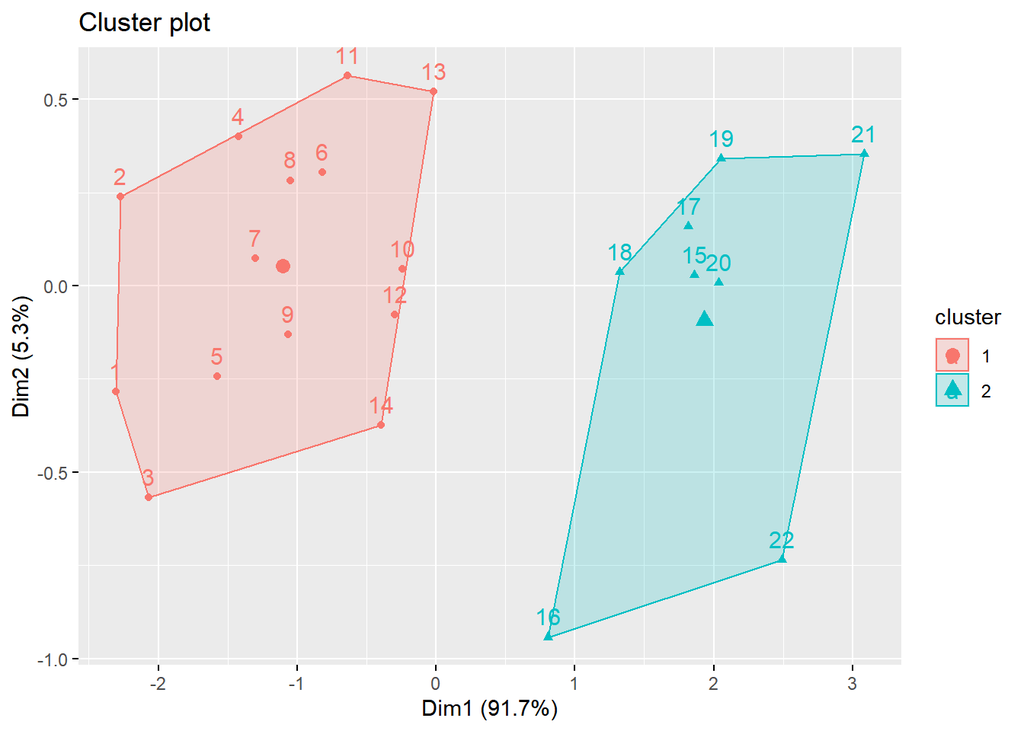

```r
fviz_cluster(k2, data=df)
```

## Hemos calculado qué objeto pertenece a qué clúster jerárquico y no-jerárquico. Incorporamos este factor a nuestra BD. Nota: aquí ocupamos el valor obtenido en el clúster jerárquico con el método de Ward pero sabemos que es el mismo que el obtenido con el método de Average Linkage

```r
cj <- cutree(clusterj1, k = 2)
df$clusterj <- as.factor(cj)
df$clusternj <- as.factor(k2$cluster)
```

## Así podemos visualizar las coincidencias

```r
table(df$clusterj, df$clusternj)
```

```
##
##      1  2
##   1 14  1
##   2  0  7
```

## Otra manera de ver las coincidencias, siempre que sean una tabla 2x2, podemos usar la función de tablas de confusión (“conf_mat”) del paquete “yardstick”

```r
#install.packages("yardstick")
library(yardstick)
cm <- conf_mat(table(df$clusterj, df$clusternj))
```

## Ahora lo podemos visualizar como un mapa de calor con la función autoplot de ggplot2

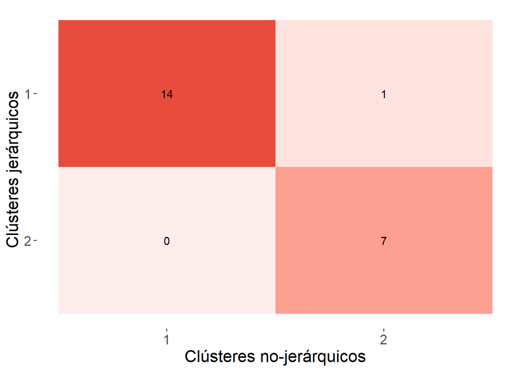

```r
autoplot(cm, type = "heatmap") + scale_fill_gradient(low="#FDEDEC", high = "#E74C3C") + xlab("Clústeres no-jerárquicos") + ylab("Clústeres jerárquicos ") + theme(text = element_text(size = 16))
```

## Otra alternativa es construirla a “mano” con tabyl de janitor y flextable

```r
df %>% tabyl(clusterj, clusternj, show_na=FALSE) %>% flextable() %>%
  theme_vanilla() %>% set_caption("clusternj") %>%
  fontsize(size = 14, part = "body") %>%
  bg(bg="#008080", part = "header") %>%
  color(color = "white", part = "header") %>%
  bg(i = 1, j = 2, bg="#EC7063", part = "body") %>%
  bg(i = 2, j = 3, bg="#FADBD8", part = "body") %>%
  bg(i = 1, j = 3, bg="#D6EAF8", part = "body") %>% autofit()
```

clusternj

| clusterj | 1 | 2 |
| --- | --- | --- |
| 1 | 14 | 1 |
| 2 | 0 | 7 |

## Comparamos los clúster de pertenencia obtenidos por el método jérarquico y el no-jerárquico. Evidenciamos que excepto 1 observación son iguales. Aquí debemos decidir con cuál nos quedamos. Para los fines de la clase, nos quedamos con los clústeres obtenidos mediante el método jerárquico, pues nos ofrece un dendrograma, muy útil desde el punto de vista de la taxonomía numérica. Finalmente comparamos nuestras variables entre los clústeres, evidenciando la existencia de diferencias estadísticamente significativas en cada caso

```r
summary(subset(df,clusterj=="1",select=Largo))
```

```
##      Largo
##  Min.   :15.30
##  1st Qu.:17.05
##  Median :18.60
##  Mean   :19.08
##  3rd Qu.:20.35
##  Max.   :26.30
```

```r
summary(subset(df,clusterj=="2",select=Largo))
```

```
##      Largo
##  Min.   :26.30
##  1st Qu.:26.95
##  Median :27.60
##  Mean   :29.43
##  3rd Qu.:31.45
##  Max.   :35.30
```

```r
wilcox.test(Largo ~clusterj,data=df,exact=F)
```

```
##
##  Wilcoxon rank sum test with continuity correction
##
## data:  Largo by clusterj
## W = 0.5, p-value = 0.0002742
## alternative hypothesis: true location shift is not equal to 0
```

```r
summary(subset(df,clusterj=="1",select=Ancho_max))
```

```
##    Ancho_max
##  Min.   : 6.50
##  1st Qu.:10.95
##  Median :13.50
##  Mean   :12.99
##  3rd Qu.:15.05
##  Max.   :18.90
```

```r
summary(subset(df,clusterj=="2",select=Ancho_max))
```

```
##    Ancho_max
##  Min.   :21.10
##  1st Qu.:22.10
##  Median :23.40
##  Mean   :23.70
##  3rd Qu.:24.25
##  Max.   :28.70
```

```r
wilcox.test(Ancho_max~clusterj,data=df,exact=F)
```

```
##
##  Wilcoxon rank sum test with continuity correction
##
## data:  Ancho_max by clusterj
## W = 0, p-value = 0.0002448
## alternative hypothesis: true location shift is not equal to 0
```

```r
summary(subset(df,clusterj=="1",select=Ancho_plataforma))
```

```
##  Ancho_plataforma
##  Min.   : 4.20
##  1st Qu.: 6.40
##  Median : 7.00
##  Mean   : 7.56
##  3rd Qu.: 8.60
##  Max.   :12.60
```

```r
summary(subset(df,clusterj=="2",select=Ancho_plataforma))
```

```
##  Ancho_plataforma
##  Min.   :11.40
##  1st Qu.:13.30
##  Median :13.40
##  Mean   :13.17
##  3rd Qu.:13.40
##  Max.   :14.00
```

```r
wilcox.test(Ancho_plataforma ~clusterj,data=df,exact=F)
```

```
##
##  Wilcoxon rank sum test with continuity correction
##
## data:  Ancho_plataforma by clusterj
## W = 1, p-value = 0.0003082
## alternative hypothesis: true location shift is not equal to 0
```

## Finalmente podemos visualizar graficamente con graficos de dispersión.

## Cada gráfico lo guardamos en un objeto para luego llamarlos

```r
c1 <- ggplot(data = df, aes(x = Largo, y = Ancho_max, color = clusterj)) + geom_point(size = 4) + theme_bw() + labs(title = "Cluster Jerárquicos")
c2 <- ggplot(data = df, aes(x = Largo, y = Ancho_max, color = clusternj)) + geom_point(size = 4) + theme_bw() + labs(title = "Cluster No jerárquicos")


c3 <- ggplot(data = df, aes(x = Largo, y = Ancho_plataforma, color = clusterj)) + geom_point(size = 4) + theme_bw() + labs(title = "Cluster Jerárquicos")
c4 <- ggplot(data = df, aes(x = Largo, y = Ancho_plataforma, color = clusternj)) + geom_point(size = 4) + theme_bw() + labs(title = "Cluster No jerárquicos")

c5 <- ggplot(data = df, aes(x = Ancho_max, y = Ancho_plataforma, color = clusterj)) + geom_point(size = 4) + theme_bw() + labs(title = "Cluster Jerárquicos")
c6 <- ggplot(data = df, aes(x = Ancho_max, y = Ancho_plataforma, color = clusternj)) + geom_point(size = 4) + theme_bw() + labs(title = "Cluster No jerárquicos")
```

## Ahora vamos a usar el paquete de patchwork para representar juntas las gráficas

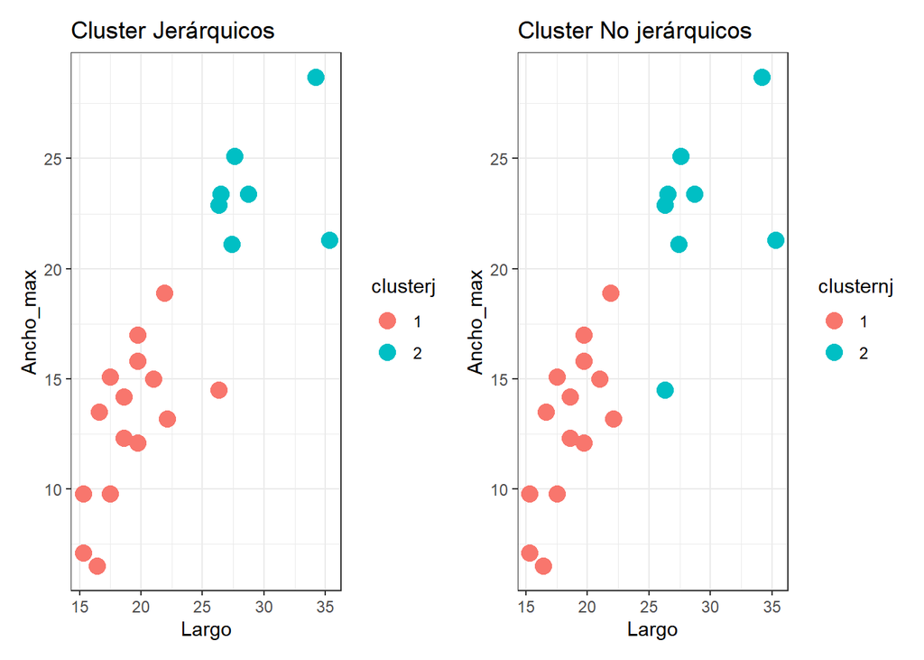

```r
#install.packages("patchwork")
library(patchwork)
c1 + c2
```

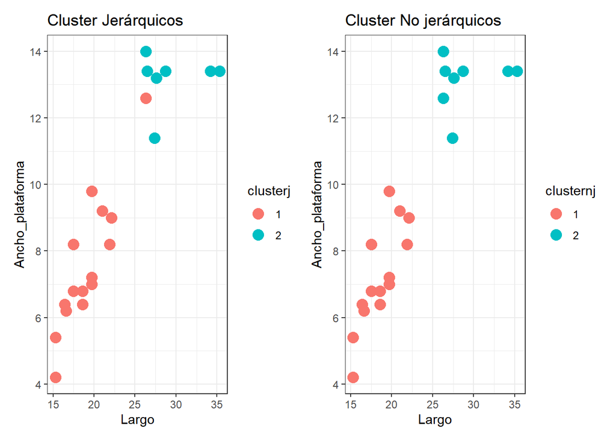

```r
c3 + c4
```

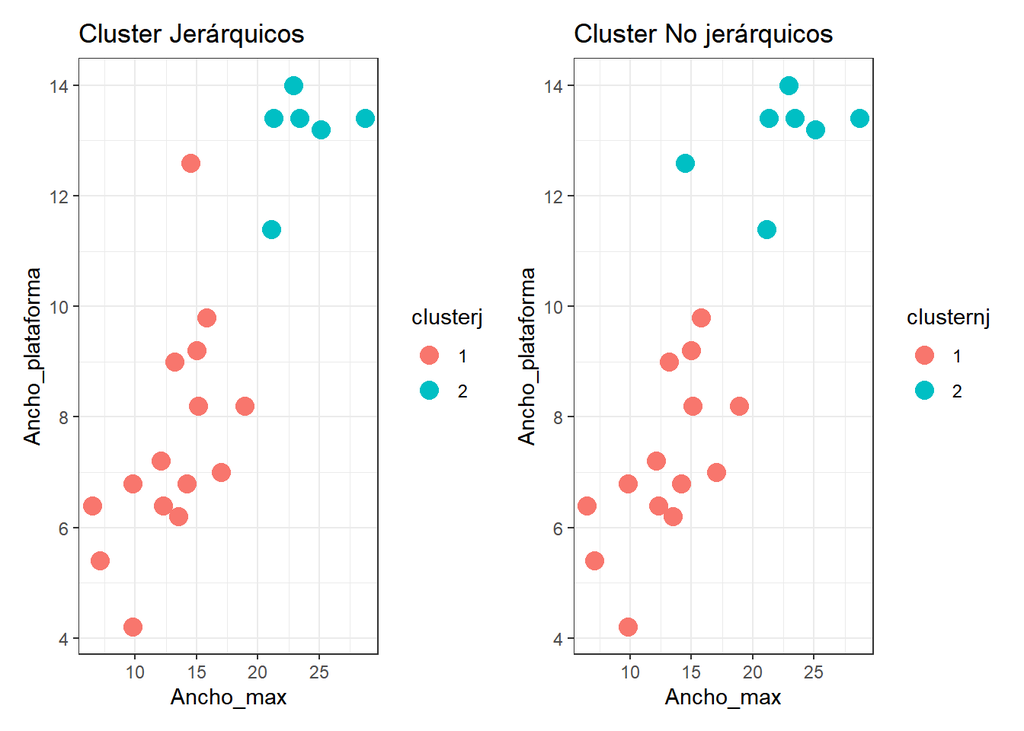

```r
c5 + c6
```